# Evaluation

Alípio Jorge

March 2021

# A real example

- Real situation
  - A hospital treats patients with **Familial Amyloidotic Polyneuropathya**
  - A disease with severe symptoms
  - Affects the nervous system
  - After diagnosis, it is not certain when the patient will have symptoms (onset)
  - A good prediction can lead to better treatment
  - *this disease is commonly known as doença dos pezinhos*
- Remeber CRISP? This was the **business problem**

# General approach

- The **machine learning problem**
  - **predict** the time a patient takes to have symptoms of the disease (age of onset)
- Approach skecthed:
  - Get the data
  - Define the features
  - Pre-process
  - **Choose** a learning algorithm
  - **Determine** hyper-parameters
  - Obtain a model
  - **Check** the model
  - Apply the model to real cases
  - Measure the **operational performance**

# Modelling

- Remember "what is machine learning?"
  - An algorithm that is able to improve its **performance** on a task
    - e.g. Predicting "age of onset"
  - Finding a **function** that **approximates** the unknown function that generates the data
    - Finding a **model** from the data
- Evaluation is about **measuring that performance**
  - Can we **trust** the learned model?
  - Can we **choose** between competing models?
  - How can we available data to both **learn** and **evaluate**?
- Besides: evaluation is often **part of the learning process**

# Measuring performance in deployment

- Our model **predicts** age of onset for new patients
  - What **really** counts:
    - lives we save
    - quality of life of the patients improved
    - reduction of cost that allows to treat more patients or spend money in other diseases
  - To measure the **operational performance** of our model
    - Predictive ability of the model
      - e.g., Root Mean Squared Error (**RMSE**)
    - Costs
      - **cost matrix** or cost function
- While **modelling** we typically focus on the **predictive ability**
  - But we must always align model evaluation with **deployment**

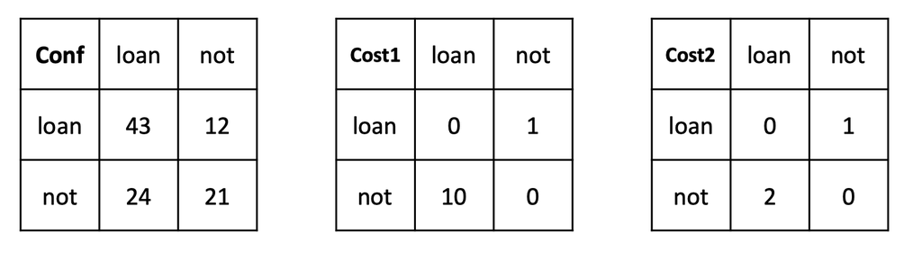

```python
# Elements of Statistical Learning
from IPython.display import Image
Image("imagens/cost-matrices.png")
```

# Estimating operational performance

- While we model we typically **do not have access** to the operational conditions
- Our **training data** $X$ has a **distribution** $\mathcal{D}$
  - We assume in operation data has the **same distribution**
- With this assumption we can **estimate** operational behavior from modeling behavior
- We want to assess if our model **generalizes well**
  - It can give useful predictions over **unseen** data

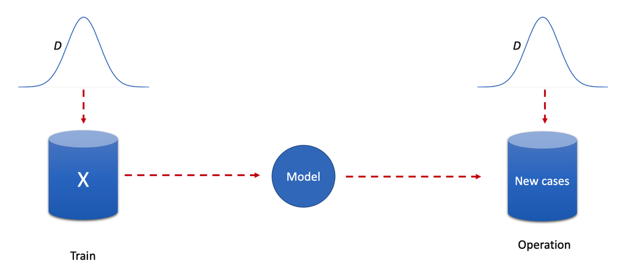

```python
from IPython.display import Image
Image("imagens/train-operation-same-distribution.png")
```

# When change happens

- But the assumption does not always exactly hold
  - $\mathcal{D}$ may **change with time** (concept drift)
    - The model is less and less useful until becoming **obsolete**
    - We use a **continuous learning** approach
      - Data streams
      - Online learning
  - $\mathcal{D}$ may **change abruptly** (concept drift)
    - The model **suddenly** becomes obsolete
      - Change detection
  - **New classes** may appear
    - Novelty detection
  - And other real life nuisances

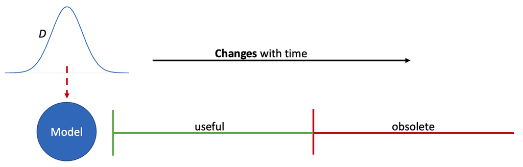

```python
from IPython.display import Image
Image("imagens/concept-drift.png")
```

# Training Error and Generalization Error

- The aim of evaluation is to **estimate** Generalization Error from **observed data** $<X,Y>$
- **Error** is a random variable
  - We want to estimate it as reliably (robustly) as possible
- **Training Error**: average loss over the training sample ($x_i \in X_{train}$, $y_i \in Y_{train}$)

$$ \text{err}_{training}=\frac{1}{N} \sum_{i=1}^N L(y_i,\hat{f}(x_i)) $$

- **Test Error** or generalization error: expected prediction error over an independent sample **given** a training set $T$
  - Notes:
    - We already have a model
    - The test set here is not fixed

$$ Err_{T} = \text{E}[L(y_i,\hat{f}(x_i))~|~T] $$

- **Expected Test Error**: the training set is not fixed, so we can have different $\hat{f}(x)$

$$ Err = \text{E}[L(y_i,\hat{f}(x_i))] $$

# Training Error

- Training error is **not a good estimate** for the generalization error (in general)
  - Complex models can exploit data increasingly
  - Training error can go to zero due to overfitting
  - Generalization error is high
- This applies to **any** predictive task:
  - Classification
  - Regression
  - Recommendation
  - etc.

# Best general approach

- Divide data in **Train** data, **Validation** data and **Test** data
  - Train: **fit** models (e.g. find parameters)
  - Validation: used for **model selection**
    - including hyper parameter tuning
  - Test: assessment of the **final model**
    - Test data **should not be seen** before final validation

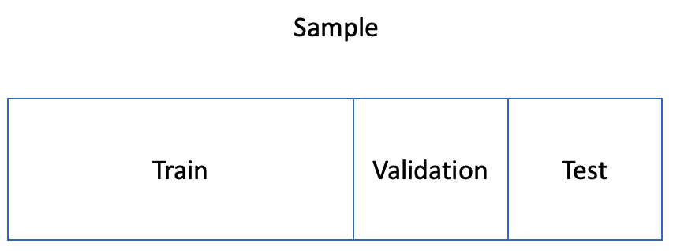

```python
from IPython.display import Image
Image("imagens/train-validation-test.png")
```

# Bias-Variance Decomposition

- We assume that $Y = f(X) + \epsilon$
  - $f$ is the true function
  - $\epsilon$ is the **irreducible error**
- If we consider the squared-error loss

$$ \text{Err}(x_0) = \text{E}[(Y-\hat{f}(x_0))^2 |X=x_0] $$

- From which we can get to

$$ \text{Err}(x_0) = \text{Irreducibe Error}+\text{Bias}^2+\text{Variance} $$

- More complex models tend to have lower bias error and higher variance error

# Optimism of the training error rate

- The training error is **optimistic**

$$ \text{err}_{training} < \text{Err}_T $$

- Why (intuitivelly)?
  - Learning **minimizes error for the sample**
  - The more expressive (complex) the model, the more error is minimized
- With $N$ training cases, it can be shown for squared error, 0-1 and other loss functions that *optimism* is at least

$$ \frac{2}{N}\sum_{i=1}^{N}\text{Cov}(\hat{y}_i,y_i) $$

- Overfitting **increases the difference** between true $y$ and predicted
  - Increasing $\text{Cov}(\hat{y}_i,y_i)$

# Cross-Validation

- K-Fold Cross Validation
  - Split the sample in $k$ segments of equal size (folds)
  - Use all folds **but one** to train a model
  - Use the **remaining fold** for error assessment (**validation**)
  - **Average** error over folds
- Cross Validation estimates the **Expected Test Error**
  - Independent of sample
  - Each fold has a different training set
- Leave-one-out
  - If the sample is very small we can make $K=N$
  - We train with **all examples but one** in each iteration
  - Leave-one-put still estimates Expected Test Error

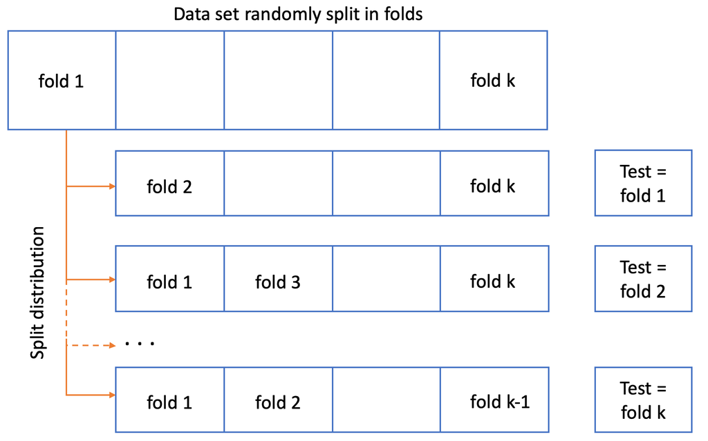

```python
from IPython.display import Image
Image("imagens/cross-validation.png")
```

# Choosing the K in KFCV

- $K=N$
  - Provides an approximately **unbiased estimator** of $\text{Err}$
  - High variance
  - Computationally **expensive**
- $K=5$
  - Lower variance
  - Bias can be a problem
    - Training sets are smaller
    - Easier to overfit
    - Error can be **overestimated**
    - Not a problem with enough data
- 5 or 10 fold-CV are recommended in general

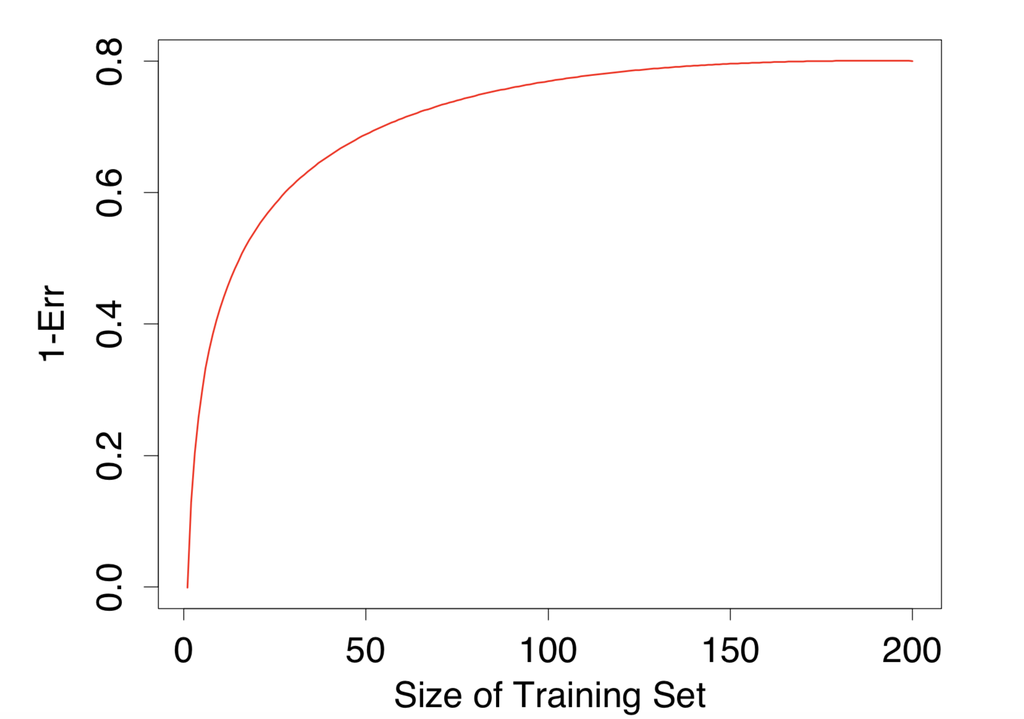

```python
# Elements of Statistical Learning
from IPython.display import Image
Image("imagens/5fcv-with-N.png")
```

# Pitfalls when using CV

- Imagine:
  - We have a genomics data-set
  - 50 examples and 5000 predictors
  - 2 equal-size classes with random labels
- (Wrong) Procedure:
  - Identify a subset of the predictors with **high correlation** with the target
  - Use CV to tune hyper-parameters and estimate the error
- What can go wrong?
  - Expected error is 50% but it can get as low as 3%
- What was the problem?
  - We used test data for selecting predictors (**data leakage**)
  - Error **grossly underestimated**

# Pitfalls when using CV

- Correct procedure
  - Divide the dataset into $K$ folds
  - For each fold $k$:
    - Find good predictors
    - Build the classifier from all folds but one
    - Predict class labels in fold $k$

# Pitfalls when using CV

- Other situations:
  - **Build features** with the **whole dataset**
  - **Discretize** with the whole dataset
  - **Impute values** with the whole dataset
  - etc.
- In general:
  - CV must be applied to the whole process
- General rule:
  - Think of the **operational conditions**
  - Training cannot benefit from test data

# Pitfalls when using CV

- Class Imbalance
  - Fraud detection
    - One class has 97% of the cases
- Normal cross validation
  - Some folds may have very little or no cases of the **small class**
  - Error is over-estimated
- **Stratified cross validation**
  - Each fold has approximately the same proportion as the whole data set

# Bootstrap Method

- **Bootstrap** is a general statistical tool
  - It can be used to estimate $\text{Err}$
- The procedure for a dataset $D$:
  - Obtain $B$ **bootstrap samples** of $D$ **with replacement** (same $N$)
  - For each sample $S$:
    - Obtain a model with $S$
    - Assess the model on the cases that were not selected for $S$
- **How many cases** we have for testing?
  - Approximately 36.8% of $N$

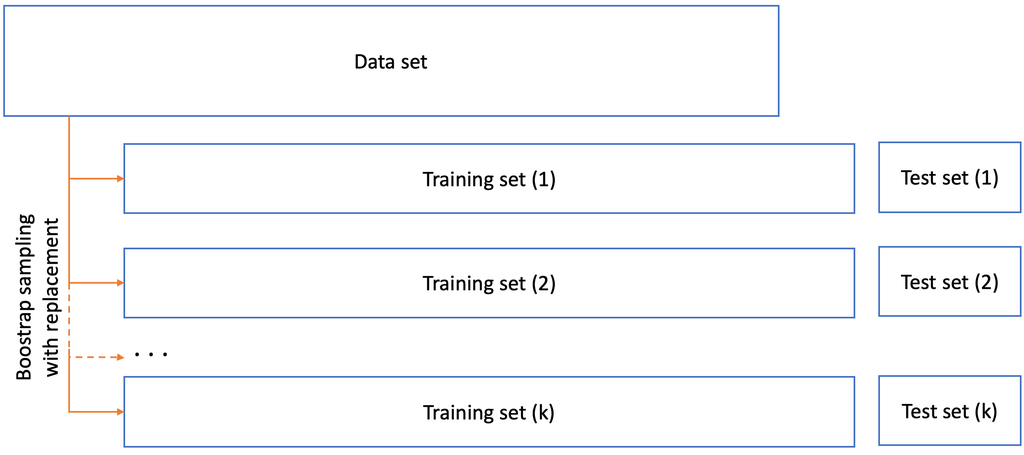

```python
from IPython.display import Image
Image("imagens/bootstrap-subsampling.png")
```

# Bootstrap Method

# Summary so far

- The aim is to estimate Generalization Error
- Error can be estimated **empirically**
- Estimating error with the training set is optimistic
  - Especially for complex/expressive models
- Train, Validation, Test separation
- Cross validation provides a balanced estimate of the Expected Test Error
- Bootstrap is an alternative no CV, but hardly preferred

## Question

- How to **distinguish** two solutions with very similar error values?

# Measuring statistical significance

- We compare two algorithms **A** and **B** using CV
  - **A** has 0.8832 accuracy
  - **B** has 0.8845 accuracy
- Is this difference **important**?
  - **Statistical significance**
    - the difference occurs most of the time
    - how likely is it to observe this difference or larger?
  - **Usefulness**
    - st. significant does not imply useful
    - does it save more lifes with fewer secondary effects?

# Measuring statistical significance

- Use **Hypothesis testing**
- 10 fold CV example with t-test
  - obtain two samples of the accuracies: $Acc_A$ and $Acc_B$
  - calculate the means $mean_A$ and $mean_B$
  - we assume that the accuracy values follow a **t-distribution** with $k-1$ degrees of freedom
  - we can use a paired **t-test**
  - **$H_0$ or Null hypothesis** is that the difference of means is zero
  - the **paired t-test** checks if we can reject $H_0$
  - the test **assumes independence** of the samples (not true)

# More on statistical significance tests

- t-test with cross validation should be avoided
  - the independence of the values does not exist
  - it gives some information though
- if we have enough data to promote independence
  - t-test is acceptable
- To compare two algorithms on multiple datasets (e.g. 30)
  - cross-validate on each dataset
  - choose a **level of significance** (typically 1% to 5%)
  - if assumptions hold use a parametric test (**t-test**)
  - if not, use non-parametric **wilcoxon signed rank** test
- To compare many algorithms on multiple datasets
  - use **Friedman** test and post-hoc **Nemenyi** with **critical distances**
- Be **careful with multiple comparisons**
  - sometimes we have to **adjust** the p-values

# Bibliography

- The Elements of Statistical Learning. Hastie, Trevor, Tibshirani, Robert, Friedman, Jerome, Springer. (chapter 7)
- Machine Learning, Tom Mitchel (Chapter 5)